# TD 7 : Modèle relationnel des données

Conversion d’un modèle E/A en un modèle relationnel

Modélisation

MCD

EA

MRD

modèle relationnel

SQL

Published

| L3 MIASHS |
| --- |
| [Université Paris Cité](https://www.u-paris.fr) |
| Année 2025 |
| [Course Homepage](https://bgentou.github.io/MA15E045/) |
| [Moodle](https://moodle.u-paris.fr/course/view.php?id=2313) |

**ImportantObjectifs**

L’objectif de cette séance est de traduire un diagramme E/A (MCD) en un modèle relationnel (MRD).

## Exercice (Supermarché)

L’équipe de conception a étudié le SI d’un supermarché et a fourni le MCD suivant pour la partie approvisionnement et mise en rayon.

La propriété “en stock chez le fournisseur” est un booléen.

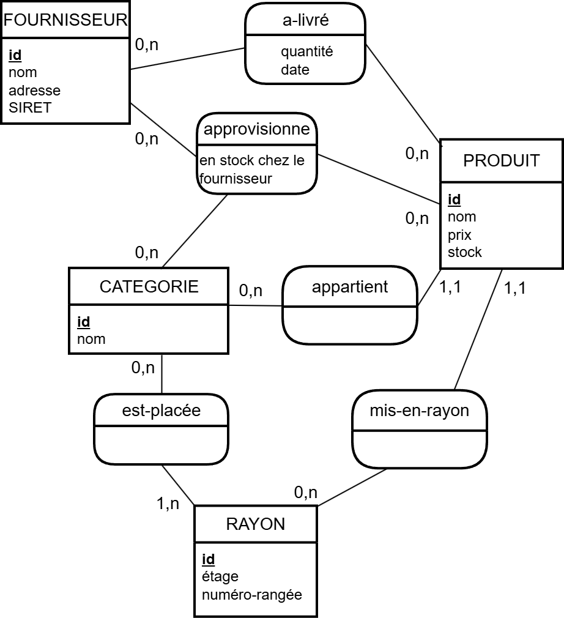

**NoteQuestion**

Convertir ce diagramme E/A en un modèle relationnel.

**NoteQuestion**

Quelles sont les clés étrangères sur lesquelles il faut ajouter une contrainte `NOT NULL` ou `UNIQUE` ?

**NoteQuestion**

Ecrire en SQL la définition des données de la partie *PRODUIT*, *CATEGORIE*, *RAYON*, en essayant d’implémenter toutes les contraintes du diagramme E/A.

Une cardinalité n’est pas codable par une contrainte de table ou de champ, laquelle ? Comment peut-on généraliser ?

**NoteQuestion**

Ce modèle E/A présente une erreur de conception, indépendamment de la connaissance du SI qu’il modélise. Laquelle ?

Comment faut-il normaliser ce modèle ?

## Exercice

On reprend un MCD élaboré dans un TD précédent :

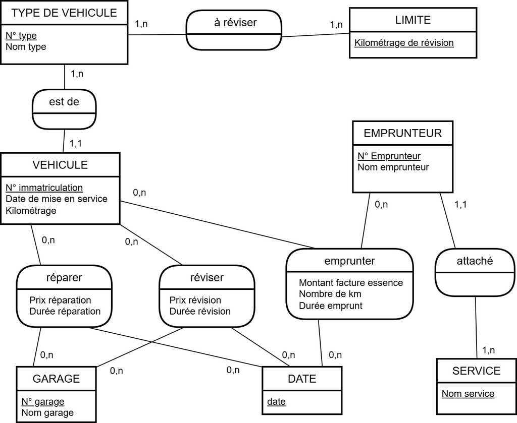

**NoteQuestion**

Convertir ce diagramme E/A en un modèle relationnel.

**NoteQuestion**

Quelles sont les clés étrangères sur lesquelles il faut ajouter une contrainte `NOT NULL` ou `UNIQUE` ?

**NoteQuestion**

Ecrire en SQL la définition des données du modèle relationnel en essayant d’implémenter les contraintes du diagramme E/A.